# Final Project Report

Gajin Kim & Jayant Shah

[output not shown]

```
Questions raised:
1. How has the average temperature changed between the start and end of Covid-19?
2. How has the temperature of densely populated cities (i.e. NYC, New York) been affected by Covid-19?
3. How has the temperature of a rural city (i.e. Waterloo, Iowa) been affected by Covid-19?
4. Main Question: How effective has the quarantine been in reducing the daily mean temperature?
```

[output not shown]

```r
# Load our cleaned data sets
waterloo_clean <- read.csv('./datasets/Waterloo_Municipal_IowaClean.csv')
nyc_clean <- read.csv('./datasets/JFK_International_NewYorkClean.csv')
```

**Question 1.**

We have two data sets for two different cities: Waterloo and New York.

To compare mean values of temperatures for pre-, during-, and post-quarantine periods, the data has loosely split up by year.

- Pre-Quarantine Period is year 2019
- During-Quarantine Period is year 2020
- Post-Quarantine Period is year 2021

In the summary below, we can observe the average temperature in Waterloo by month between 2019 and 2021.

```r
w_summary
```

```
##          2019  2020  2021
## Min.    15.60 23.20 10.60
## 1st Qu. 30.75 37.58 43.38
## Median  48.40 47.40 57.90
## Mean    47.21 49.67 53.17
## 3rd Qu. 69.67 64.85 72.28
## Max.    76.70 77.40 75.50
```

Likewise, we can observe the average temperature in New York City by month between 2019 and 2021 in the figure below.

```r
nyc_summary
```

```
##          2019  2020  2021
## Min.    32.40 38.50 33.20
## 1st Qu. 39.60 44.70 45.98
## Median  56.10 54.55 62.20
## Mean    54.67 56.20 58.31
## 3rd Qu. 69.73 69.18 71.23
## Max.    78.80 79.30 76.90
```

We will plot the corresponding graph to compare the Monthly Average Temperature for both cities in order to observe any significant differences between our graphs.

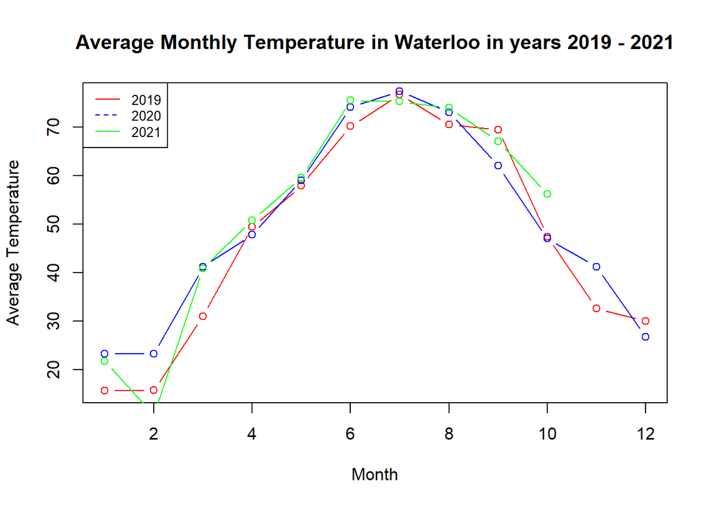

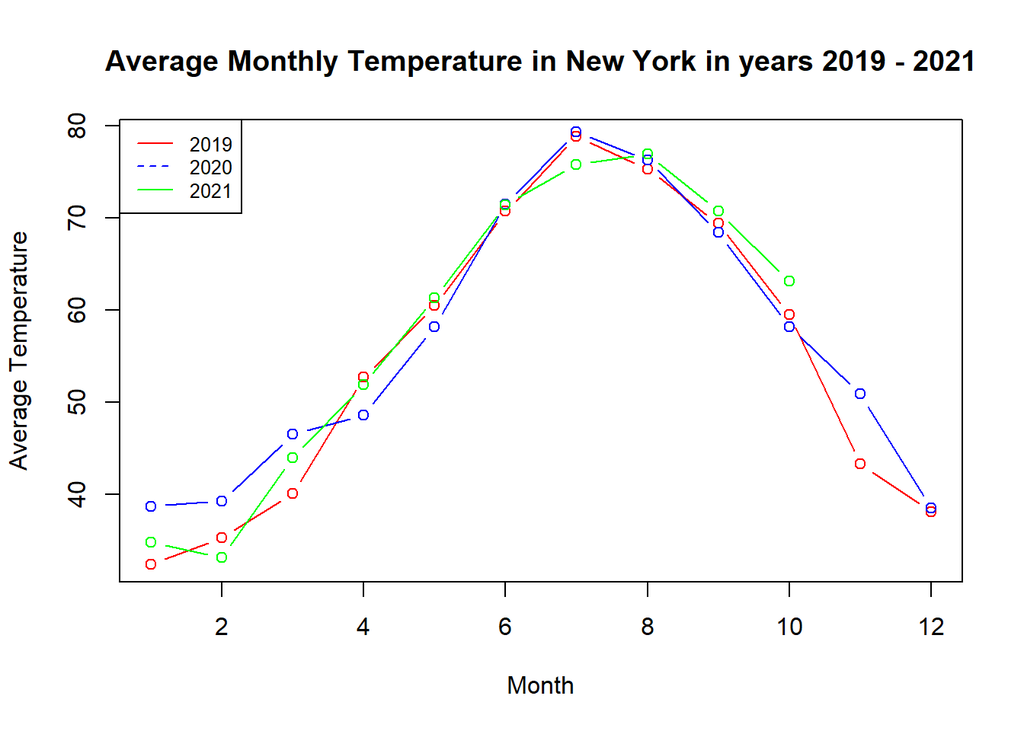

As we can see, we cannot say if there is a difference between the average monthly temperature in pre-, during-, and post-covid periods in Waterloo or New York. Thus, we heed to test hypothesis about the equivalence of mean values for these periods. We will use t-test:

```r
t_w1
```

```
##
##  Welch Two Sample t-test
##
## data:  w_pre_monthly$MonthlyMeanTemperature and w_d_monthly$MonthlyMeanTemperature
## t = -0.28886, df = 21.722, p-value = 0.7754
## alternative hypothesis: true difference in means is not equal to 0
## 95 percent confidence interval:
##  -20.12097  15.20431
## sample estimates:
## mean of x mean of y
##  47.20833  49.66667
```

As we can see, the p-value is 0.7754, which is greater than 0.05. It means that we cannot reject the null-hypothesis about equality of means. Thus, the true difference in means for pre-Covid and during-Covid period in Waterloo is equal to zero.

```r
t_w2
```

```
##
##  Welch Two Sample t-test
##
## data:  w_pre_monthly$MonthlyMeanTemperature and w_post_monthly$MonthlyMeanTemperature
## t = -0.62254, df = 19.061, p-value = 0.541
## alternative hypothesis: true difference in means is not equal to 0
## 95 percent confidence interval:
##  -26.00083  14.07750
## sample estimates:
## mean of x mean of y
##  47.20833  53.17000
```

As we can see, the p-value is 0.541, which is greater than 0.05. It means that we cannot reject the null-hypothesis about equality of means. Thus, the true difference in means for pre-Covid and post-Covid period in Waterloo is equal to zero.

```r
t_w3
```

```
##
##  Welch Two Sample t-test
##
## data:  w_d_monthly$MonthlyMeanTemperature and w_post_monthly$MonthlyMeanTemperature
## t = -0.38336, df = 18.009, p-value = 0.7059
## alternative hypothesis: true difference in means is not equal to 0
## 95 percent confidence interval:
##  -22.70185  15.69518
## sample estimates:
## mean of x mean of y
##  49.66667  53.17000
```

As we can see, the p-value is 0.7059, which is greater than 0.05. It means that we cannot reject the null-hypothesis about equality of means. Thus, the true difference in means for during-Covid and post-Covid period in Waterloo is equal to zero.

```r
t_ny1
```

```
##
##  Welch Two Sample t-test
##
## data:  nyc_pre_monthly$MonthlyMeanTemperature and nyc_d_monthly$MonthlyMeanTemperature
## t = -0.23747, df = 21.721, p-value = 0.8145
## alternative hypothesis: true difference in means is not equal to 0
## 95 percent confidence interval:
##  -14.85326  11.80326
## sample estimates:
## mean of x mean of y
##    54.675    56.200
```

As we can see, the p-value is 0.8145, which is greater than 0.05. It means that we cannot reject the null-hypothesis about equality of means. Thus, the true difference in means for pre-Covid and during-Covid period in New York is equal to zero.

```r
t_ny2
```

```
##
##  Welch Two Sample t-test
##
## data:  nyc_pre_monthly$MonthlyMeanTemperature and nyc_post_monthly$MonthlyMeanTemperature
## t = -0.51387, df = 19.349, p-value = 0.6132
## alternative hypothesis: true difference in means is not equal to 0
## 95 percent confidence interval:
##  -18.42245  11.15245
## sample estimates:
## mean of x mean of y
##    54.675    58.310
```

As we can see, the p-value is 0.6132, which is greater than 0.05. It means that we cannot reject the null-hypothesis about equality of means. Thus, the true difference in means for pre-Covid and post-Covid period in New York is equal to zero.

```r
t_ny3
```

```
##
##  Welch Two Sample t-test
##
## data:  nyc_d_monthly$MonthlyMeanTemperature and nyc_post_monthly$MonthlyMeanTemperature
## t = -0.31327, df = 18.395, p-value = 0.7576
## alternative hypothesis: true difference in means is not equal to 0
## 95 percent confidence interval:
##  -16.23895  12.01895
## sample estimates:
## mean of x mean of y
##     56.20     58.31
```

As we can see, the p-value is 0.7576, which is greater than 0.05. It means that we cannot reject the null-hypothesis about equality of means. Thus, the true difference in means for during-Covid and post-Covid period in New York is equal to zero.

Thus, as we can see, the average monthly temperature in pre-, during-, and post-COVID periods does not have statistically significant difference, i.e. we may conclude that the average monthly temperature did not change significantly in COVID period both in Waterloo and New York.

**Question 2.**

We will being by utilizing the ‘Year’ variable as a factor.

```r
nyc_clean$Year<-as.factor(nyc_clean$Year)
```

By using this data and ‘Year’ as factor, we can build a boxplot to observe the average daily temperature in New York in years 2019 (pre-COVID time), 2020 (during-COVID time), and 2021 (post-COVID time):

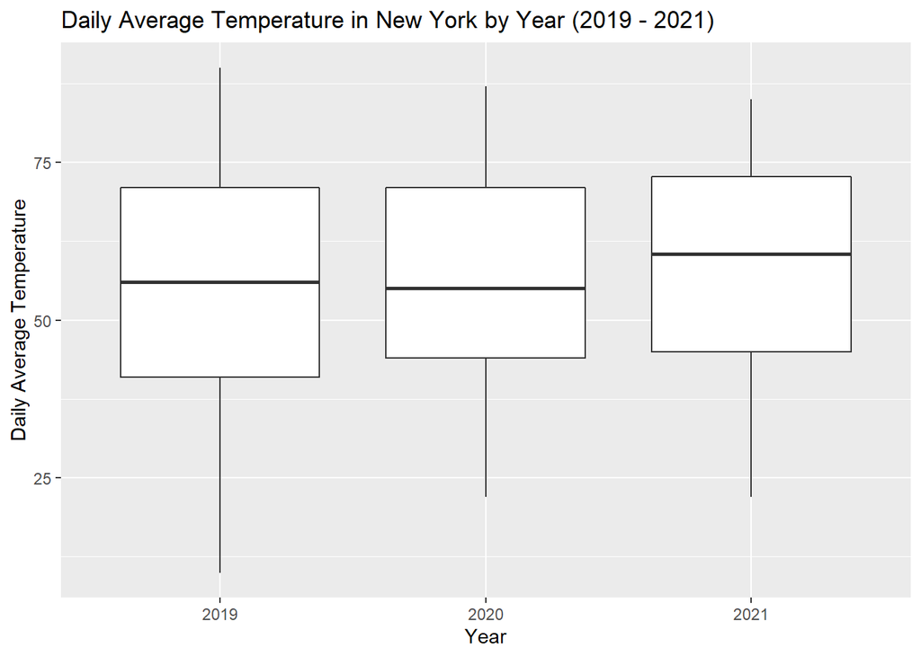

As we can see from the boxplot, we can assume that the average daily temperature in New York during COVID-19 has changed: it is slightly greater for year 2020 compared to 2019; it’s greater for year 2021 compared to 2019 and 2020. The summary statistics:

```
## $`2019`
##    Min. 1st Qu.  Median    Mean 3rd Qu.    Max.    NA's
## "10.00" "41.00" "56.00" "55.02" "71.00" "90.00"    "12"
##
## $`2020`
##    Min. 1st Qu.  Median    Mean 3rd Qu.    Max.    NA's
## "22.00" "44.00" "55.00" "56.49" "71.00" "87.00"    "12"
##
## $`2021`
##    Min. 1st Qu.  Median    Mean 3rd Qu.    Max.    NA's
## "22.00" "45.00" "60.50" "58.08" "72.75" "85.00"    "10"
```

As we can see from the summary statistic, our assumption should be right. Let check it with t-test:

The results are:

```r
tt_ny1
```

```
##
##  Welch Two Sample t-test
##
## data:  nyc_pre$DailyAverageDryBulbTemperature and nyc_during$DailyAverageDryBulbTemperature
## t = -1.2225, df = 720.55, p-value = 0.2219
## alternative hypothesis: true difference in means is not equal to 0
## 95 percent confidence interval:
##  -3.816250  0.887408
## sample estimates:
## mean of x mean of y
##  55.02192  56.48634
```

As we can see, the p-value of the test is 0.2219, which is greater than 0.05. It means that at 95% confidence level, we cannot reject the null-hypothesis: the true difference in means is equal to zero. Thus, there is no difference in daily average temperature in New York in pre- and during-COVID periods.

```r
tt_ny2
```

```
##
##  Welch Two Sample t-test
##
## data:  nyc_pre$DailyAverageDryBulbTemperature and nyc_post$DailyAverageDryBulbTemperature
## t = -2.4115, df = 685.75, p-value = 0.01615
## alternative hypothesis: true difference in means is not equal to 0
## 95 percent confidence interval:
##  -5.547524 -0.568150
## sample estimates:
## mean of x mean of y
##  55.02192  58.07975
```

As we can see, the p-vlue is 0.01615, which is lower than 0.05. Thus, we should reject the null-hypothesis about equality of means. Thus, there is a statistically significant difference in pre- and post- daily average temperature in New York. We can check if our assumption is true and the post-COVID average daily temperature is higher than in pre-COVID period in NY:

```r
tt_ny2_new<-t.test(nyc_post$DailyAverageDryBulbTemperature, nyc_pre$DailyAverageDryBulbTemperature, alternative = "greater")
tt_ny2_new
```

```
##
##  Welch Two Sample t-test
##
## data:  nyc_post$DailyAverageDryBulbTemperature and nyc_pre$DailyAverageDryBulbTemperature
## t = 2.4115, df = 685.75, p-value = 0.008075
## alternative hypothesis: true difference in means is greater than 0
## 95 percent confidence interval:
##  0.9692921       Inf
## sample estimates:
## mean of x mean of y
##  58.07975  55.02192
```

As we can see, the p-value is 0.008075, which is lower than 0.05: we should reject the null-hypothesis. It means that the true difference in means between post-COVID daily average temperature and pre-COVID daily average temperature is greater than zero. Thus, the post-COVID daily average temperature is higher than the pre-COVID daily average temperature in New York.

Let see what we have for during- and post-COVID daily average temperature difference:

```r
tt_ny3
```

```
##
##  Welch Two Sample t-test
##
## data:  nyc_during$DailyAverageDryBulbTemperature and nyc_post$DailyAverageDryBulbTemperature
## t = -1.3212, df = 669.01, p-value = 0.1869
## alternative hypothesis: true difference in means is not equal to 0
## 95 percent confidence interval:
##  -3.9614224  0.7745908
## sample estimates:
## mean of x mean of y
##  56.48634  58.07975
```

As we can see, the p-value is 0.1869, which is greater than 0.05, which means that we cannot reject the null-hypothesis. Thus, the difference between the mean values for daily average temperature in during- and post-COVID periods are equal to zero. Thus, there is no statistically significant difference in daily average temperatures in during- and post-COVID periods.

Thus, we can conclude that the post-COVID daily average temperature in New York is higher than in pre-COVID period, but it’s not different from during-COVID period. The daily average temperature in pre-COVID and during-COVID period are not significantly different.

**Question 3.**

```r
waterloo_clean$Year<-as.factor(waterloo_clean$Year)
```

By using this data and ‘Year’ as factor, we can build a boxplot to see the average daily temperature in Waterloo in years 2019 (pre-COVID time), 2020 (during-COVID time), and 2021 (post-COVID time):

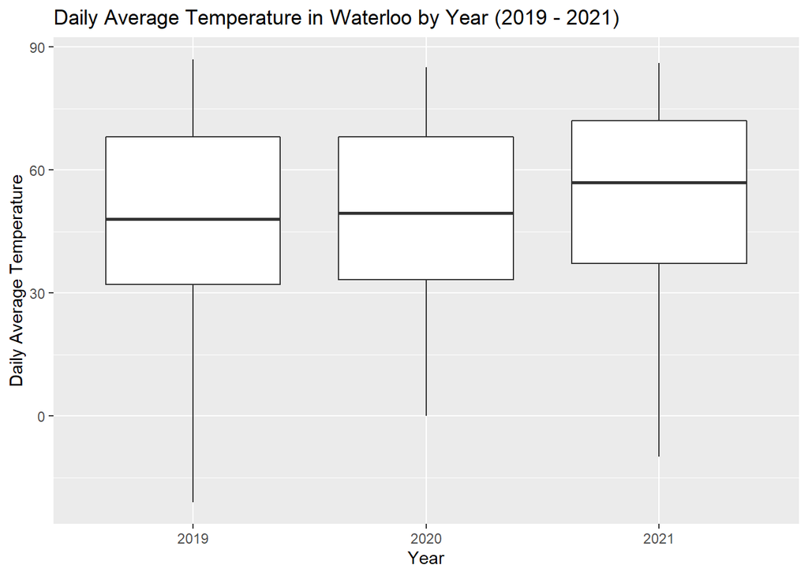

As we can see from the boxplot, we can assume that the average daily temperature in this city during COVID-19 has changed: it is slightly greater for year 2020 compared to 2019; it’s greater for year 2021 compared to 2019 and slightly greater compared to year 2020. The summary statistics:

```r
tapply(waterloo_clean$DailyAverageDryBulbTemperature, waterloo_clean$Year, function(x) format(summary(x)))
```

```
## $`2019`
##     Min.  1st Qu.   Median     Mean  3rd Qu.     Max.     NA's
## "-21.00" " 32.00" " 48.00" " 47.61" " 68.00" " 87.00"     "12"
##
## $`2020`
##    Min. 1st Qu.  Median    Mean 3rd Qu.    Max.    NA's
## " 0.00" "33.25" "49.50" "49.98" "68.00" "85.00"    "12"
##
## $`2021`
##     Min.  1st Qu.   Median     Mean  3rd Qu.     Max.     NA's
## "-10.00" " 37.25" " 57.00" " 52.82" " 72.00" " 86.00"     "10"
```

As we can see from the summary statistic, our assumption should be right. Let check it with t-test:

The results are:

```r
tt_w1
```

```
##
##  Welch Two Sample t-test
##
## data:  waterloo_pre$DailyAverageDryBulbTemperature and waterloo_during$DailyAverageDryBulbTemperature
## t = -1.4724, df = 719.99, p-value = 0.1414
## alternative hypothesis: true difference in means is not equal to 0
## 95 percent confidence interval:
##  -5.5427720  0.7919823
## sample estimates:
## mean of x mean of y
##  47.60548  49.98087
```

As we can see, the p-value of the test is 0.1414, which is greater than 0.05. It means that at 95% confidence level, we cannot reject the null-hypothesis: the true difference in means is equal to zero. Thus, there is no difference in daily average temperature in Waterloo in pre- and during-COVID periods.

```r
tt_w2
```

```
##
##  Welch Two Sample t-test
##
## data:  waterloo_pre$DailyAverageDryBulbTemperature and waterloo_post$DailyAverageDryBulbTemperature
## t = -3.0033, df = 682.35, p-value = 0.002768
## alternative hypothesis: true difference in means is not equal to 0
## 95 percent confidence interval:
##  -8.627019 -1.806194
## sample estimates:
## mean of x mean of y
##  47.60548  52.82209
```

As we can see, the p-value is 0.002768, which is lower than 0.05. Thus, we should reject the null-hypothesis about equality of means. Thus, there is a statistically significant difference in pre- and post- daily average temperature in Waterloo. We can check if our assumption is true and the post-COVID average daily temperature is higher than in pre-COVID period in Waterloo:

```r
tt_w2_new<-t.test(waterloo_post$DailyAverageDryBulbTemperature, waterloo_pre$DailyAverageDryBulbTemperature, alternative = "greater")
tt_w2_new
```

```
##
##  Welch Two Sample t-test
##
## data:  waterloo_post$DailyAverageDryBulbTemperature and waterloo_pre$DailyAverageDryBulbTemperature
## t = 3.0033, df = 682.35, p-value = 0.001384
## alternative hypothesis: true difference in means is greater than 0
## 95 percent confidence interval:
##  2.355691      Inf
## sample estimates:
## mean of x mean of y
##  52.82209  47.60548
```

As we can see, the p-value is 0.001384, which is lower than 0.05: we should reject the null-hypothesis. It means that the true difference in means between post-COVID daily average temperature and pre-COVID daily average temperature is greater than zero. Thus, the post-COVID daily average temperature is higher than the pre-COVID daily average temperature in Waterloo.

Let see what we have for during- and post-COVID daily average temperature difference:

```r
tt_w3
```

```
##
##  Welch Two Sample t-test
##
## data:  waterloo_during$DailyAverageDryBulbTemperature and waterloo_post$DailyAverageDryBulbTemperature
## t = -1.7197, df = 660.84, p-value = 0.08595
## alternative hypothesis: true difference in means is not equal to 0
## 95 percent confidence interval:
##  -6.085231  0.402808
## sample estimates:
## mean of x mean of y
##  49.98087  52.82209
```

As we can see, the p-value is 0.08595, which is greater than 0.05. But it is lower than 0.1, which means that at 90% of confidence we can say that the mean values of daily average temperature for during- and post-COVID periods are different. We can check this:

```r
tt_w3_new<-t.test(waterloo_post$DailyAverageDryBulbTemperature, waterloo_during$DailyAverageDryBulbTemperature, alternative = "greater")
tt_w3_new
```

```
##
##  Welch Two Sample t-test
##
## data:  waterloo_post$DailyAverageDryBulbTemperature and waterloo_during$DailyAverageDryBulbTemperature
## t = 1.7197, df = 660.84, p-value = 0.04297
## alternative hypothesis: true difference in means is greater than 0
## 95 percent confidence interval:
##  0.1199159       Inf
## sample estimates:
## mean of x mean of y
##  52.82209  49.98087
```

As we can see, the p-value is 0.04297, which is lower than 0.05: we should reject the null-hypothesis. It means that the true difference in means between mean values of daily average temperature in post- and during-COVID period is greater than zero. Thus, the mean value of post-COVID daily average temperature is higher than the mean value of during-COVID daily average temperature in Waterloo.

Thus, we can conclude that the post-COVID daily average temperature in Waterloo is higher than in pre-COVID and during-COVID periods. The daily average temperature in pre-COVID and during-COVID period is not significantly different.

**Question 4. & Conclusion to Project Analysis**

Based on the previous analysis, the quarantine has not been effective in reducing daily mean temperature or average temperature in general. Post-COVID average daily temperature is higher than pre-COVID average daily temperature both for New York and Waterloo. We suspect that this result can be attributed to the fact that despite people were staying indoors more often during/post Covid-19, they were also utilizing electricity and ordering food more frequently than before.

```
Contribution Statements:

Gajin Kim -
Both Jayant and I worked on all parts of the project from beginning, middle, and finish. That said, we determined that it would be more optimal for each of us to prioritize certains parts of the project given our schedules. Some of the things I primarily focused on were procuring adequate datasets, cleaning the datasets, and creating the presentation. We both made contributions to the project proposal and analysis.
```